# Presentation

```r
library(tidyverse)
install.packages('knitr')
library(knitr)
# Might need to modify next line to load the file from the location where you downloaded it
df <- read_csv("data_for_datathon_2014_2016.csv") # Loads the Data Set into the object df

# Cleaning data
df <- df |> mutate( # Will change the variables in the df data set
  Vaccinations = case_when(is.na(Vaccinations) ~ "NV", .default = Vaccinations), # Reclassifies Missing Data in Vaccination as "N" per code book.
  ReproductiveStatus = case_when(is.na(ReproductiveStatus) ~ "UN", .default = ReproductiveStatus), # Reclassifies Missing Data in Vaccination as "N" per code book.
  BodyCondition = case_when( # Begins to modify BodyCondition
    as.character(BodyCondition) == "1" ~ "emaciated", # Changes 1 to emaciated
    as.character(BodyCondition) == "2" ~ "thin", # Changes 2 to thin
    as.character(BodyCondition) == "3" ~ "healthy wild", # Changes 3 to healthy wild
    as.character(BodyCondition) == "4" ~ "extra fat reserves", # Changes 4 to Extra Fat Reserve
    as.character(BodyCondition) == "5" ~ "extreme fat reserves" # Changes 5 to Extreme Fat Reserves
  )
)

summary(df)
```

```
##     Island           SamplingYear    GridCode
##  Length:4975        Min.   :2014   Length:4975
##  Class :character   1st Qu.:2014   Class :character
##  Mode  :character   Median :2015   Mode  :character
##                     Mean   :2015
##                     3rd Qu.:2016
##                     Max.   :2016
##
##     TrapDate                    NightNumber      TrapNumber
##  Min.   :2014-07-16 00:00:00   Min.   :1.000   Min.   :  1.00
##  1st Qu.:2014-08-24 00:00:00   1st Qu.:2.000   1st Qu.:  4.00
##  Median :2015-08-12 00:00:00   Median :3.000   Median :  8.00
##  Mean   :2015-08-25 01:31:27   Mean   :3.392   Mean   : 18.87
##  3rd Qu.:2016-08-18 00:00:00   3rd Qu.:5.000   3rd Qu.: 11.00
##  Max.   :2016-11-30 00:00:00   Max.   :6.000   Max.   :108.00
##
##   TrapResult           Pittag          CaptureType            Sex
##  Length:4975        Length:4975        Length:4975        Length:4975
##  Class :character   Class :character   Class :character   Class :character
##  Mode  :character   Mode  :character   Mode  :character   Mode  :character
##
##
##
##
##     AgeClass         Weight       Weight_units       BodyCondition
##  Min.   :0.000   Min.   :  0.72   Length:4975        Length:4975
##  1st Qu.:1.000   1st Qu.:  1.73   Class :character   Class :character
##  Median :1.000   Median :  2.02   Mode  :character   Mode  :character
##  Mean   :1.557   Mean   : 49.49
##  3rd Qu.:3.000   3rd Qu.:  2.30
##  Max.   :4.000   Max.   :910.00
##  NA's   :2840    NA's   :2808
##  ReproductiveStatus Vaccinations
##  Length:4975        Length:4975
##  Class :character   Class :character
##  Mode  :character   Mode  :character
##
##
##
##
```

```r
df <- drop_na(df, AgeClass, Weight, BodyCondition) # Removes the missing values (NA) using the variables AgeClass, Weight, and BodyCondition

nrow(df)
```

```
## [1] 1967
```

```r
mean_weight<-mean(df$Weight)
sd_weight<-sd(df$Weight)
mean_weight
```

```
## [1] 1.940275
```

```r
sd_weight #printing the values
```

```
## [1] 0.4140872
```

```r
count_df <- table(df$Sex) # Using the 'Sex' variable from the `df` data set, we count the frequencies of each category with the table function and storing it in rs_df.
count_df # Printing out the contents of "rs_df"
```

```
##
## Female   Male
##    923   1044
```

```r
prop.table(count_df) # Computing the Proportions of "rs_df"
```

```
##
##    Female      Male
## 0.4692425 0.5307575
```

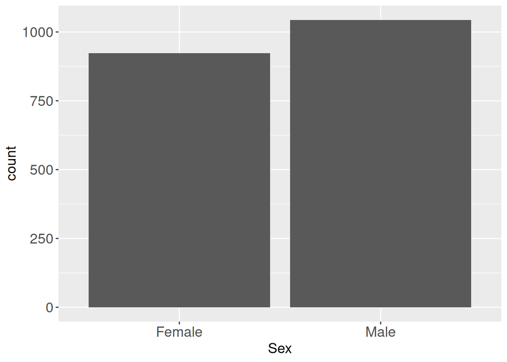

```r
ggplot(df) + # Setting up the data to create a plot.
  geom_bar(aes(Sex)) + # Creating a bar chart based on the variable "ReproductiveStatus"
  theme(axis.title = element_text(size = 14), axis.text = element_text(size = 14))
```

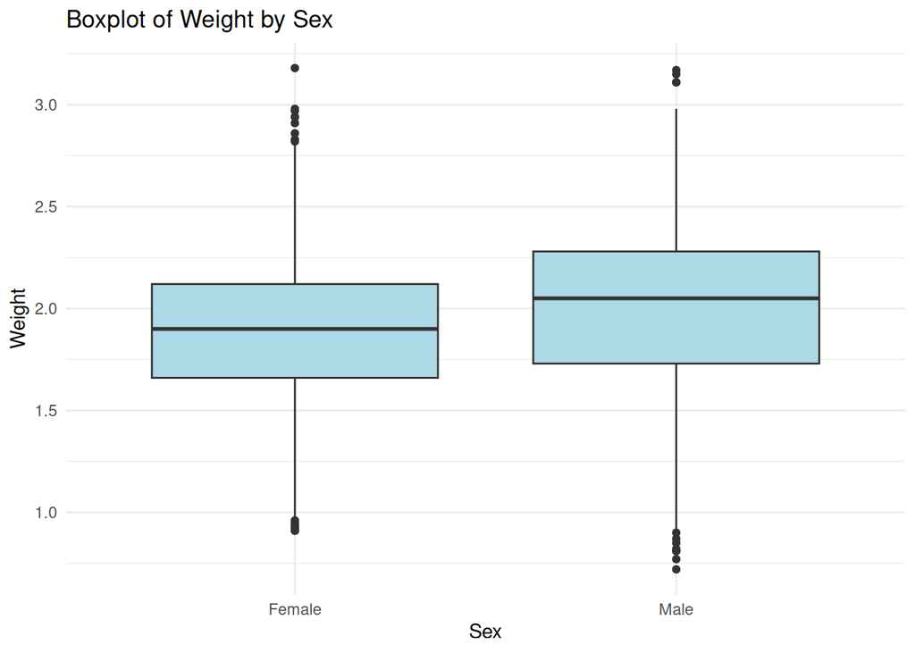

```r
ggplot(df, aes(x = Sex, y = Weight)) +
  geom_boxplot(fill = "lightblue") +
  labs(
    title = "Boxplot of Weight by Sex",
    x = "Sex",
    y = "Weight"
  ) + theme_minimal()
```

```r
weight_summary <- df %>%
  group_by(Sex) %>%
  summarise(
    mean_weight = mean(Weight),
    sd_weight = sd(Weight),
    .groups = "drop"
  )
weight_summary
```

```
## # A tibble: 2 × 3
##   Sex    mean_weight sd_weight
##   <chr>        <dbl>     <dbl>
## 1 Female        1.88     0.386
## 2 Male          1.99     0.431
```

```r
weight_summary_yearly <- df %>%
  group_by(Sex, SamplingYear) %>%
  summarise(
    mean_weight = mean(Weight, na.rm = TRUE),
    sd_weight = sd(Weight, na.rm = TRUE),
    .groups = "drop"
  ) #group the data by Sex and Year and calculate mean and standard deviation of weight
weight_summary_yearly
```

```
## # A tibble: 6 × 4
##   Sex    SamplingYear mean_weight sd_weight
##   <chr>         <dbl>       <dbl>     <dbl>
## 1 Female         2014        1.95     0.362
## 2 Female         2015        1.85     0.409
## 3 Female         2016        1.86     0.373
## 4 Male           2014        2.08     0.405
## 5 Male           2015        1.95     0.451
## 6 Male           2016        1.99     0.419
```

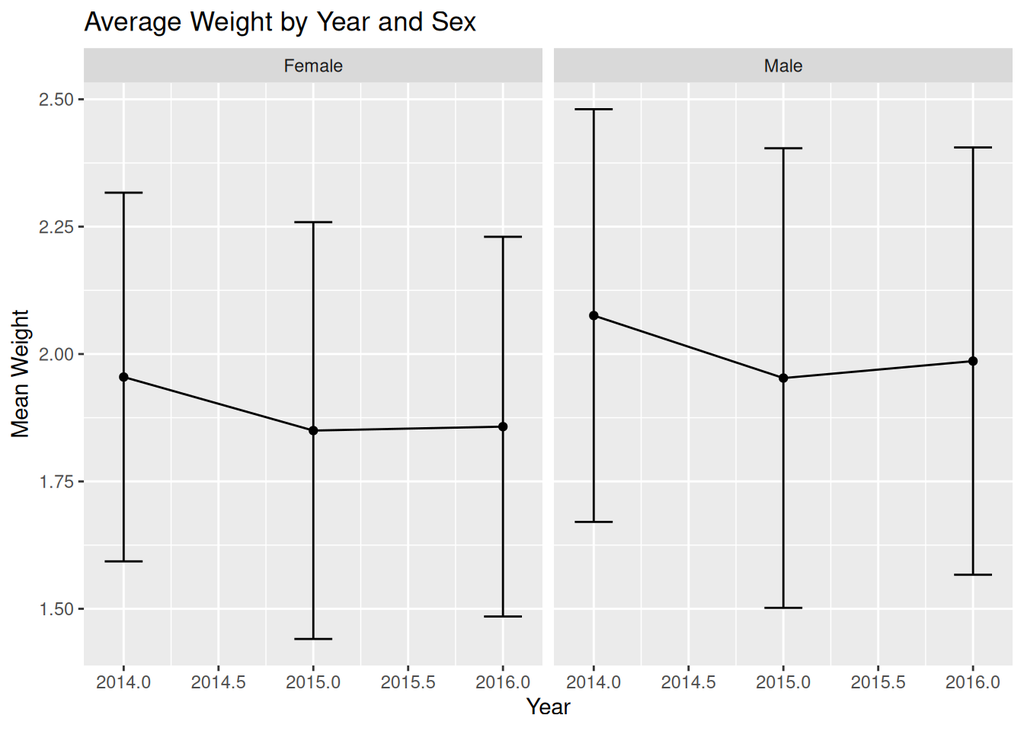

```r
ggplot(weight_summary_yearly, aes(x = SamplingYear, y = mean_weight)) +
  geom_line() +
  geom_point() +
  geom_errorbar(aes(ymin = mean_weight - sd_weight,
                    ymax = mean_weight + sd_weight), width = 0.2) +
  facet_wrap(~ Sex) +
  labs(
    title = "Average Weight by Year and Sex",
    y = "Mean Weight",
    x = "Year"
  )
```

```r
#Santa Rosa Fox population

SR_df<-filter(df,Island=="SRI")

#San Miguel Fox population
SM_df<-filter(df,Island=="SMI")
```

The fox weight has decreased over the span of 3 years.

Some things to keep in mind when analyzing the fox weight, the majority of the foxes are male (53% to 47%, rounded), which means the weight will inherently run higher as the structure of a male is larger than a female.

This can be seen with the graph on line 39-41. We can see how it effects the weight class by running lines 44-50. By using group_by, we can find that the average weight for females (1.88) kilograms is less than males, (1.99) kilograms.

By looking at the average by year, we can find that the female weight has decreased, 2014, the average weight was 1.95, 2015, 1.85, and 1.86 in 2016, meaning overall a loss of 0.09 kilograms.

Looking at the male population, by looking at the average by year, the male weight has also decreased. In 2014, the average weight was 2.08, in 2015, the average was 1.95, and 1.99 in 2016, meaning an overall a loss of 0.09 kilograms.

**Challenge Questions: 1. Do the foxes on different islands have the same weight? Is there an island where the foxes are significantly heavier than others?**

Foxes on different islands do not have the same weight, as the SRI island has a wider range of weights based on the graph on lines 95-101. SRI has both lighter and heavier foxes

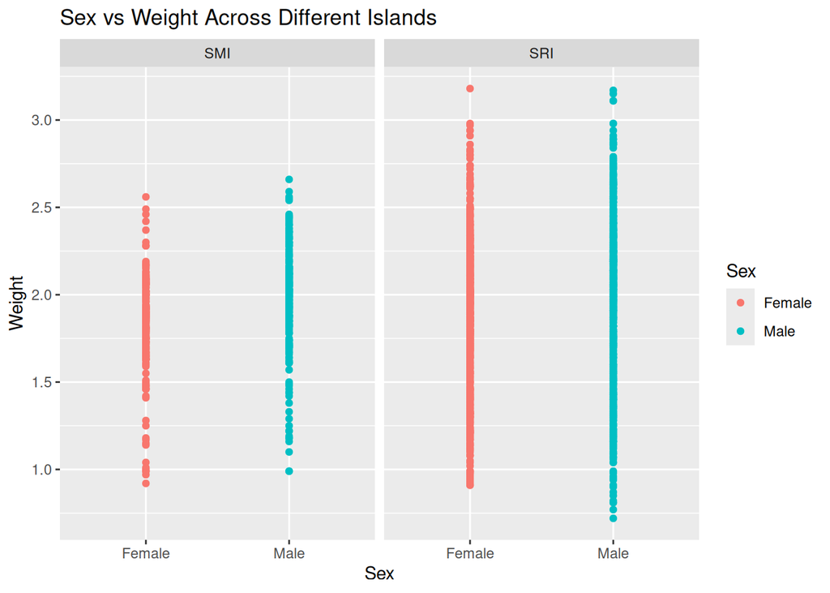

```r
ggplot(df, aes(x = Sex, y = Weight, color = Sex)) +
  geom_point() +
  facet_wrap(~Island) +
  labs(title = "Sex vs Weight Across Different Islands",
       x = "Sex",
       y = "Weight",
       color = "Sex")
```

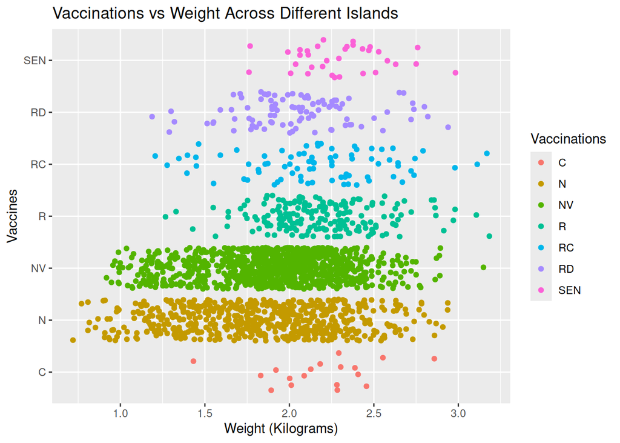

```r
# Do vaccinated foxes have a different weight compared to unvaccinated ones? To answer this, study the relationship between Weight and Vaccinations
ggplot(df, aes(x = Weight, y = Vaccinations, color = Vaccinations)) +
  geom_jitter() +
  labs(title = "Vaccinations vs Weight Across Different Islands",
       x = "Weight (Kilograms)",
       y = "Vaccines",
       color = "Vaccinations")
```

3. **The dataset has a variable called BodyCondition. What proportion of foxes are well nourished? Do some islands have a larger proportion of “fat” foxes than others? How does BodyCondition connect with Weight? For the latter, you could look into scatter plots.** If we consider emaciated and thin as not well-nourished, then 0.4702593 are well nourished. With body condition and weight, the heavier the fox, the better the body condition/the more well nourished.

```r
#The dataset has a variable called BodyCondition. What proportion of foxes are well nourished? Do some islands have a larger proportion of “fat” foxes than others? How does BodyCondition connect with Weight? For the latter, you could look into scatter plots.

# proportion overall
body_df <- table(df$BodyCondition)
body_df
```

```
##
##            emaciated   extra fat reserves extreme fat reserves
##                   81                  203                   11
##         healthy wild                 thin
##                  711                  961
```

```r
prop.table(body_df)
```

```
##
##            emaciated   extra fat reserves extreme fat reserves
##          0.041179461          0.103202847          0.005592272
##         healthy wild                 thin
##          0.361464159          0.488561261
```

```r
well_nourished = 0.103202847 + 0.005592272 +  0.361464159
well_nourished
```

```
## [1] 0.4702593
```

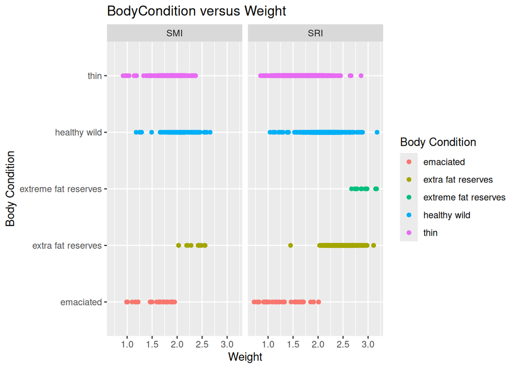

```r
# Body Condition and Weight
ggplot(df, aes(x = Weight, y = BodyCondition, color=BodyCondition)) +
  geom_point() +
  facet_wrap(~Island) +
  labs(title = "BodyCondition versus Weight",
       x = "Weight",
       y = "Body Condition",
       color ="Body Condition")
```